# Лабораторная работа №14

Администрирование сетевых подсистем

Иванов Сергей Владимирович, НПИбд-01-23

Российский университет дружбы народов, Москва, Россия

26 ноября 2025

# Цель работы

Приобретение навыков настройки доступа групп пользователей к общим ресурсам по протоколу SMB.

# Задание

1. Установите и настройте сервер Samba
2. Настройте на клиенте доступ к разделяемым ресурсам
3. Напишите скрипты для Vagrant, фиксирующие действия по установке и настройке сервера Samba для доступа к разделяемым ресурсам во внутреннем окружении виртуальных машин server и client. Соответствующим образом необходимо внести изменения в Vagrantfile

# Выполнение лабораторной работы

## Настройка сервера Samba

Запускаю виртуальную машину Server. (рис. 1)

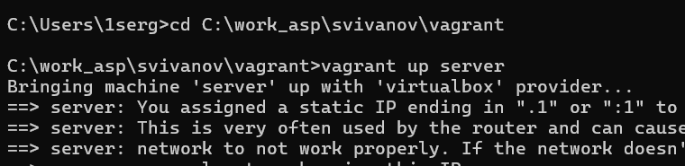

Запуск Server

## Настройка сервера Samba

На сервере установим необходимые пакеты: (рис. 2)

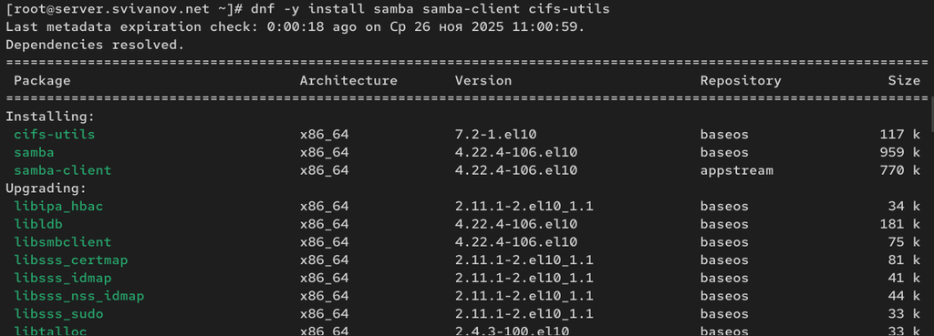

Установка необходимого ПО

## Настройка сервера Samba

Создадим группу sambagroup для пользователей, которые будут работать с Sambaсервером (рис. 3)

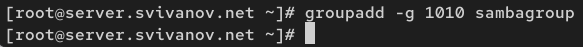

Создание группы

## Настройка сервера Samba

Добавим пользователя к группе sambagroup (рис. 4)

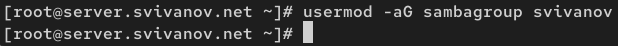

Добавление в группу

## Настройка сервера Samba

Создадим общий каталог, в который будем монтировать разделяемые ресурсы (рис. 5)

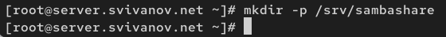

Создание каталога

## Настройка сервера Samba

В файле /etc/samba/smb.conf: изменим параметр рабочей группы (рис. 6)

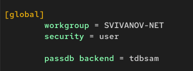

Редактирование конф.файла

## Настройка сервера Samba

В конце файла добавим раздел с описанием общего доступа к разделяемому ресурсу /srv/sambashare: (рис. 7)

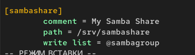

Редактирование конф.файла

## Настройка сервера Samba

Убедимся, что не сделали синтаксических ошибок в файле (рис. 8)

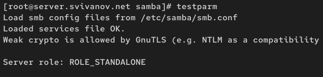

Проверка синт. ошибок

## Настройка сервера Samba

Запустим демон Samba и посмотрим его статус: (рис. 9)

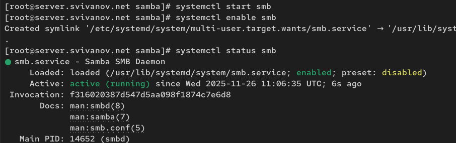

Запуск Samba

## Настройка сервера Samba

Для проверки наличия общего доступа попробуем подключиться к серверу с помощью smbclient: (рис. 10)

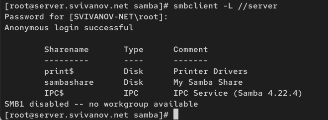

Проверка наличия общего доступа

## Настройка сервера Samba

Посмотрим файл конфигурации межсетевого экрана для Samba (рис. 11)

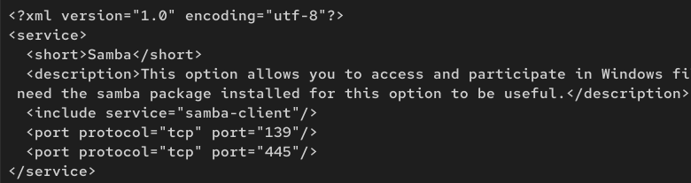

Просмотр файла конфигурации

## Настройка сервера Samba

Настроим межсетевой экран: (рис. 12)

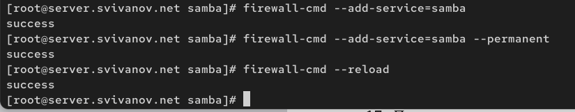

Настройка firewall

## Настройка сервера Samba

Настроим права доступа для каталога с разделяемым ресурсом: (рис. 13)

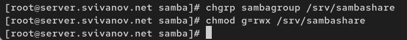

Настройка прав доступа

## Настройка сервера Samba

Посмотрим контекст безопасности SELinux: (рис. 14)

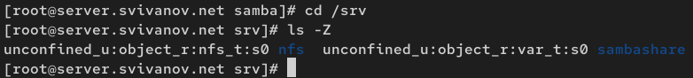

Просмотр SELinux

## Настройка сервера Samba

Настроим контекст безопасности SELinux для каталога с разделяемым ресурсом: (рис. 15)

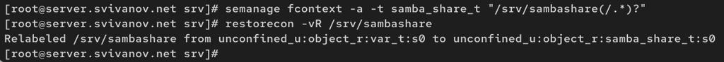

Настройка SELinux

## Настройка сервера Samba

Проверим, что контекст безопасности изменился: (рис. 16)

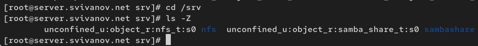

Просмотр SELinux

## Настройка сервера Samba

Разрешим экспортировать разделяемые ресурсы для чтения и записи: (рис. 17)

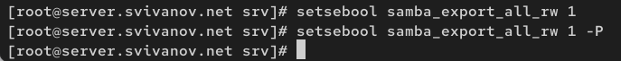

Рашрешение экспортирования

## Настройка сервера Samba

Посмотрим UID пользователя и в какие группы он включён (рис. 18)

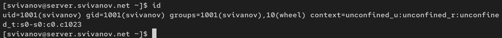

Просмотр UID пользователя

## Настройка сервера Samba

Под пользователем попробуем создать файл на разделяемом ресурсе: (рис. 19)

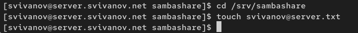

Попытка создания файла

## Настройка сервера Samba

Добавим пользователя в базу пользователей Samba: (рис. 20)

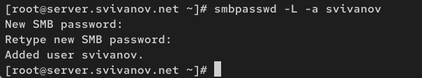

Добавление пользователя в базу

## Монтирование файловой системы Samba на клиенте

Запускаю машину Client (рис. 21)

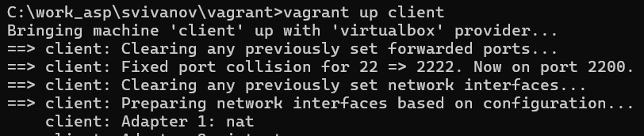

Запуск client

## Монтирование файловой системы Samba на клиенте

На клиенте установим необходимые пакеты: (рис. 22)

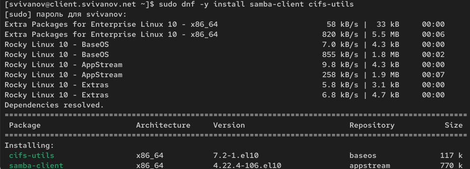

Установка необходимого ПО

## Монтирование файловой системы Samba на клиенте

На клиенте посмотрим файл конфигурации межсетевого экрана для клиента Samba: (рис. 23)

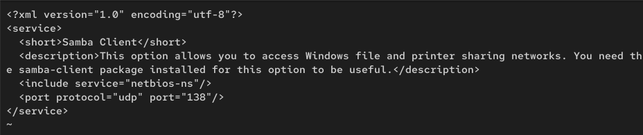

Просмотр конф. файла

## Монтирование файловой системы Samba на клиенте

На клиенте настроим межсетевой экран: (рис. 24)

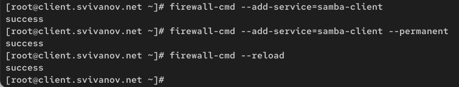

Настройка firewall

## Монтирование файловой системы Samba на клиенте

На клиенте создадим группу sambagroup и добавим в неё пользователя: (рис. 25)

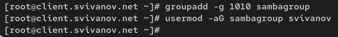

Создание группы

## Монтирование файловой системы Samba на клиенте

На клиенте в файле конфигурации /etc/samba/smb.conf изменим параметр рабочей группы: (рис. 26)

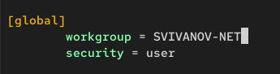

Редактирование smb.conf

## Монтирование файловой системы Samba на клиенте

Для проверки наличия общего доступа попробуем подключиться с клиента к серверу (рис. 27)

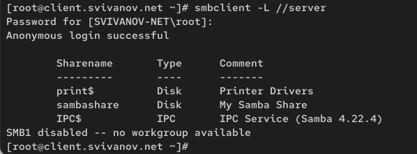

Проверка наличия общего доступа

## Монтирование файловой системы Samba на клиенте

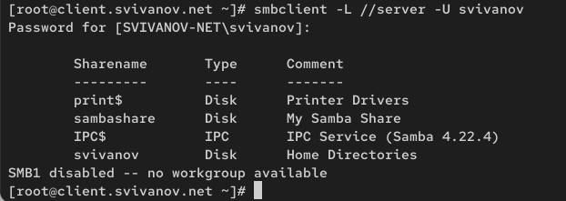

## Монтирование файловой системы Samba на клиенте

На клиенте создадим точку монтирования и получим доступ к общему ресурсу: (рис. 29)

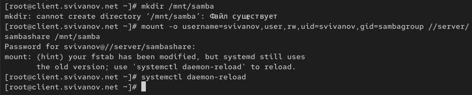

Создание точки монтирования и проверка доступа

## Монтирование файловой системы Samba на клиенте

Убедимся, что svivanov может записывать файлы на разделяемом ресурсе: (рис. 30)

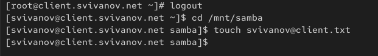

Создание файла на общем ресурсе

## Монтирование файловой системы Samba на клиенте

Отмонтируем каталог /mnt/samba: (рис. 31)

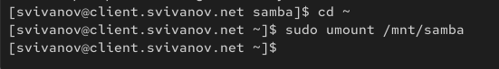

Отмонтирование каталога

## Настройка работы с Samba с помощью файла учётных данных

Для настройки работы с Samba с помощью файла учётных данных: (a) создадим файл smbusers в каталоге /etc/samba/ (рис. 32)

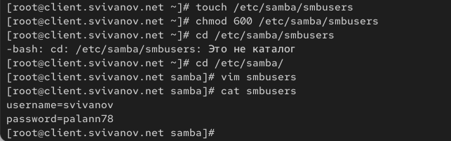

Создание файла

## Монтирование файловой системы Samba на клиенте

2. в файле /etc/fstab добавим следующую строку: (рис. 33)

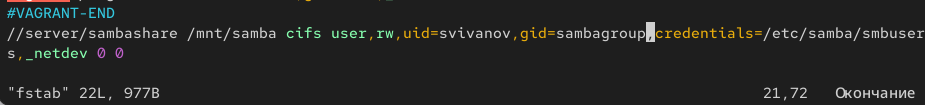

Редактирование fstab

## Монтирование файловой системы Samba на клиенте

3. Подмонтируем общий ресурс: mount -a (рис. 34)

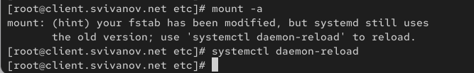

Подмонтирование общего ресурса

## Монтирование файловой системы Samba на клиенте

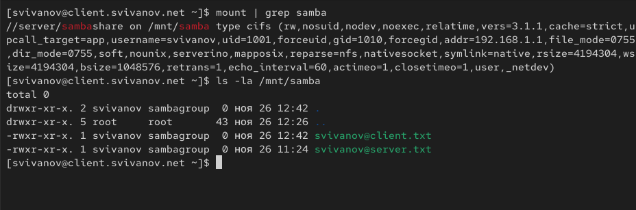

Перезагрузка и проверка

## Внесение изменений в настройки внутреннего окружения виртуальных машин

На машине server перейдем в каталог для внесения изменений, создадим в нём каталог smb, в который поместим конфигурационные файлы: (рис. 36)

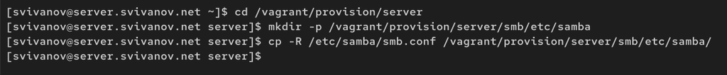

Создание каталогов и копирование конф.файлов

## Внесение изменений в настройки внутреннего окружения виртуальных машин

Создадим скрипт (рис. 37)

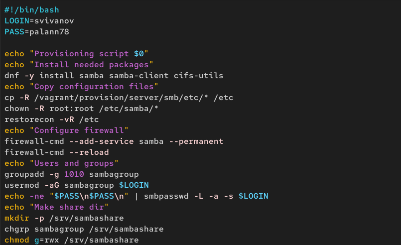

Создание скрипта

## Внесение изменений в настройки внутреннего окружения виртуальных машин

На машине client перейдем в каталог для внесения изменений, создадим в нём каталог smb, в который поместим конфигурационные файлы: (рис. 38)

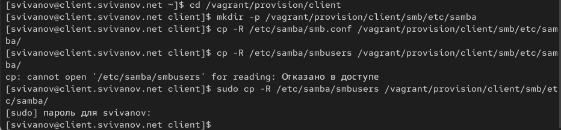

Создание каталогов и копирование конф.файлов

## Внесение изменений в настройки внутреннего окружения виртуальных машин

Создадим скрипт

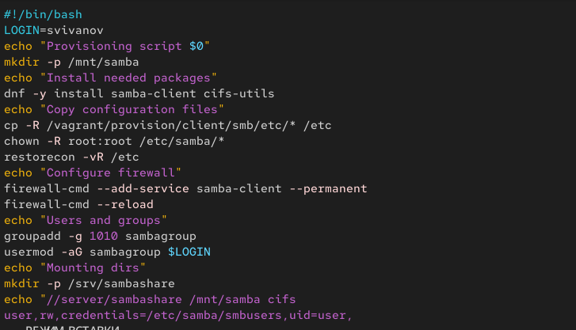

Создание скрипта

## Внесение изменений в настройки внутреннего окружения виртуальных машин

Для отработки скриптов во время загрузки машин server и client в файле Vagrantfile необходимо добавить: (рис. 40)

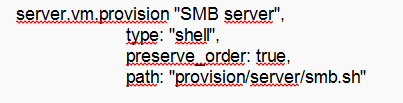

Редактирование Vagrantfile

## Внесение изменений в настройки внутреннего окружения виртуальных машин

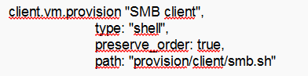

Редактирование Vagrantfile

## Вывод

В ходе выполнения лабораторной работы мы приобрели навыки настройки доступа групп пользователей к общим ресурсам по протоколу SMB.